# AMRC

## Assumption Details

The following charts provide the simulated range of assumptions used while testing the model, with the average value highlighted in red.

- `WACC` - Our team calculated the most likely range of the weighted average cost of capital for Ameresco. But we do not have a precice number, only an estimate. Variation in WACC will change valuation, so we include WACC in the simulation model. The mean value (in red) is 7.05%

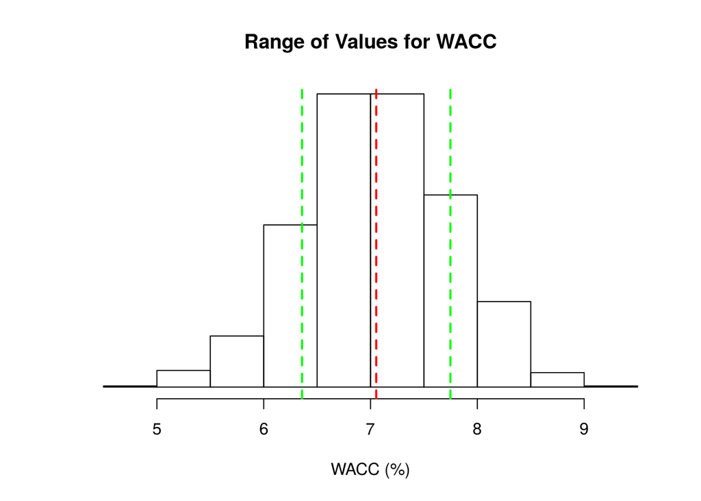

- `LT_CAGR` - In a discounted free cash flow (DFCF) valuation, you make an assumption on long term growth to create a terminal value. We used a conservative value of 2% of that, but variation of that assumption can swing the valuation so it is included. The mean value (in red) is 2.01%

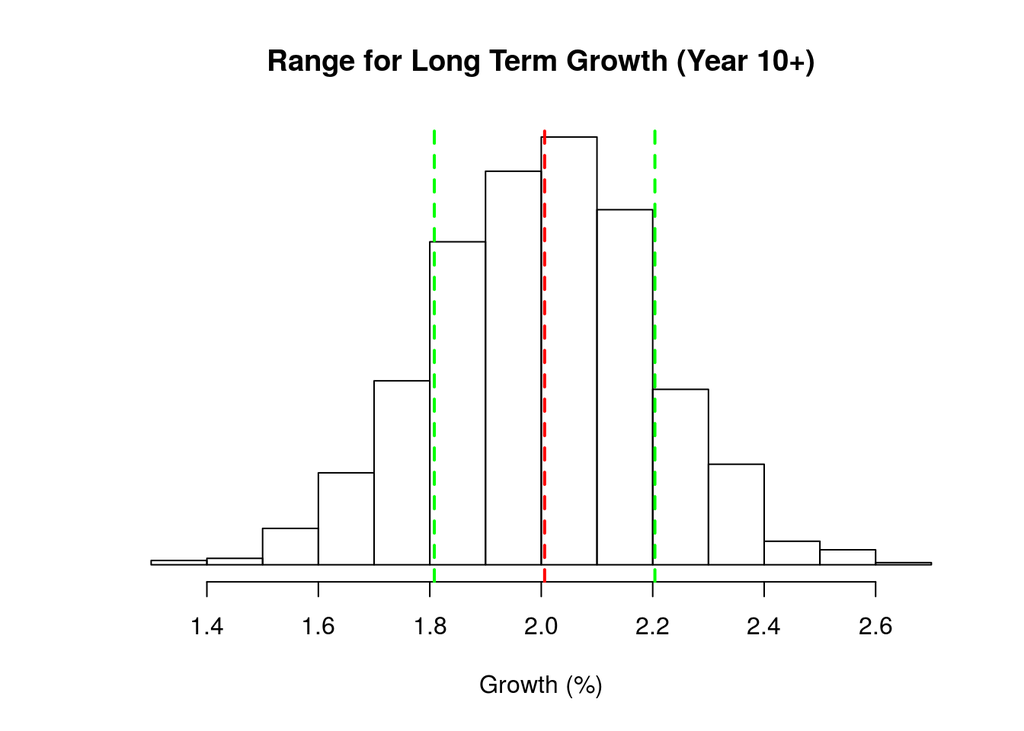

- `CAGR_19` - Capital IQ provided assumptions for the growth of free cash flow in 2017 and 2018. In order to create the valuation, we created a major assumption: 2019 will have a strong year of growth, and then growth will taper off after that. So the growth rate in 2019 is a major assumption that must be stress tested. The mean value (in red) is 43.81%

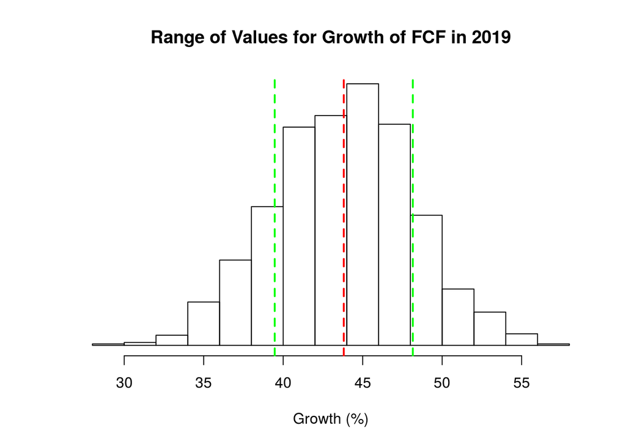

- `Decay` - No business can sustain high growth over the long term. So we used a power law curve to model the rate at which growth will taper off in the model. By creating variation in the exponent in the power law function, we can simulate a quick decrease in growth or a longer extention of growth. The mean value (in red) is -1.22

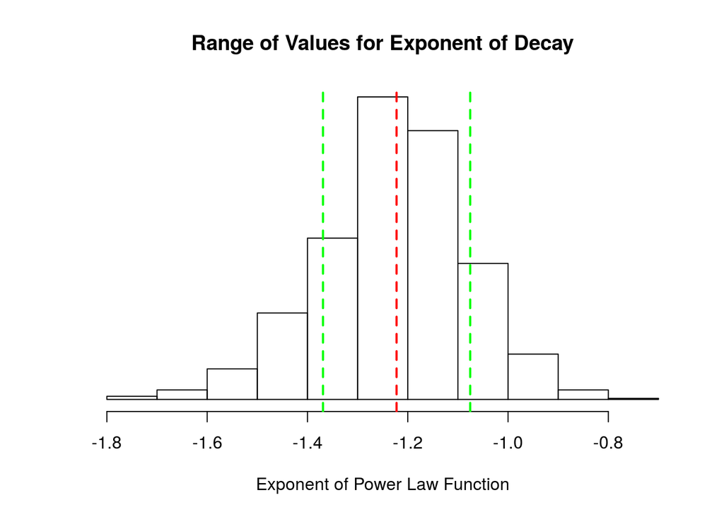